# Analyzing Monitoring Activity Data

## Step 1: Load and preprocess data

```r
data <- read.csv("activity.csv")
```

## Step 2: What is the mean total number of steps taken per day?

#### Calculate the total number of steps taken per day.

```r
total.steps <- aggregate(steps ~ date, data, sum)
```

#### Create histogram of steps taken each day.

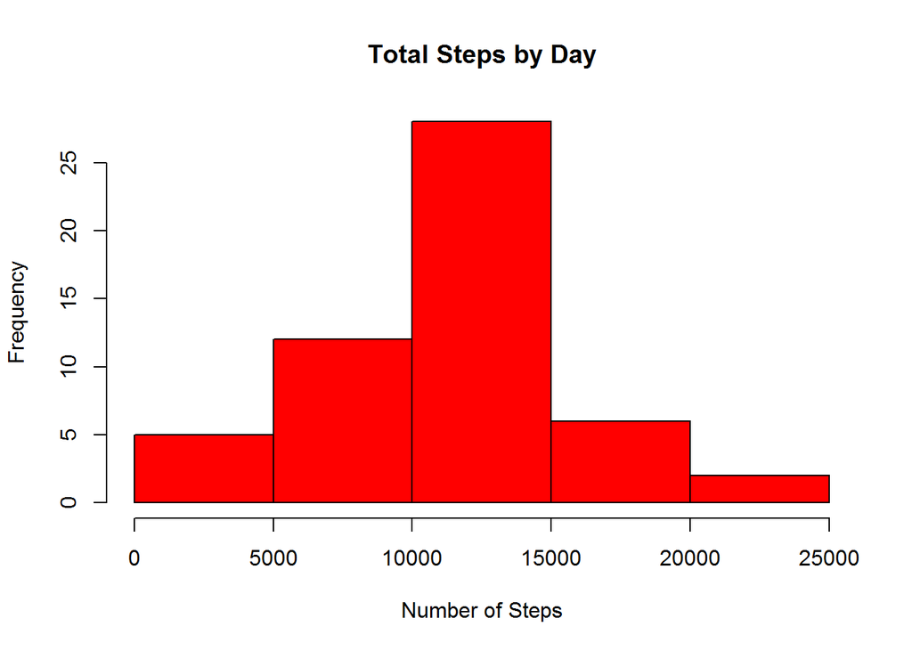

```r
library(ggplot2)
hist(total.steps$steps,
     main = "Total Steps by Day",
     xlab = "Number of Steps",
     col = "red")
```

#### Calculate and report the mean and median of the total number of steps taken each day.

```r
step.mean <- mean(total.steps$steps)
step.mean #Average of 10766.19 steps per day.
```

```
## [1] 10766.19
```

```r
step.median <- median(total.steps$steps)
step.median #Median is 10765 steps per day.
```

```
## [1] 10765
```

## Step 3: What is the average daily activity pattern?

This step requries the creation of a time series plot of five minute intervals and average number of steps taken, averaged across all days.

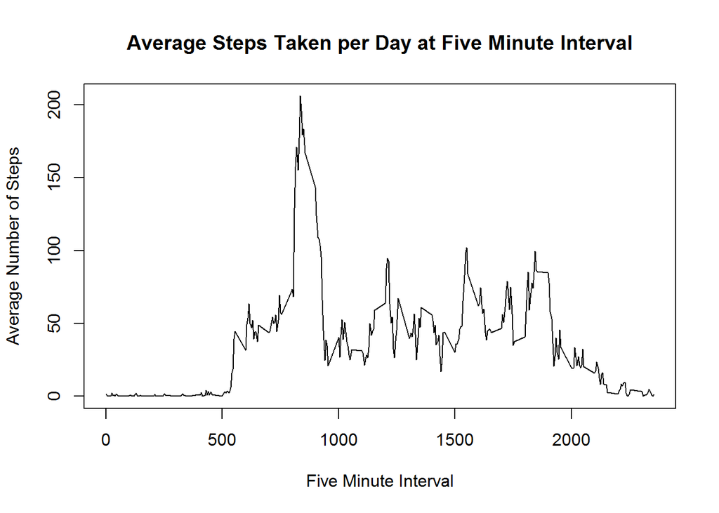

```r
step.interval <- aggregate(steps ~ interval, data, mean)
plot(step.interval$interval,
     step.interval$steps, type = "l",
     main = "Average Steps Taken per Day at Five Minute Interval",
     xlab = "Five Minute Interval",
     ylab = "Average Number of Steps")
```

#### Which 5-minute interval, on average across all the days in the dataset, contains the maximum number of steps?

```r
max.interval <- step.interval[which.max(step.interval$steps),1]
max.interval #Interval 835
```

```
## [1] 835
```